# Changes in the Canine Plasma Lipidome after Short- and Long-Term Excess Glucocorticoid Exposure

Data Analysis for the Manuscript ‘Sieber-Ruckstuhl, Burla, et al., 2019’

Nadja S. Sieber-Ruckstuhl, Bo Burla, Susanne Spoerel, Florence Schmid, Claudio Venzin, Amaury Cazenave-Gassiot, Anne K. Bendt, Federico Torta, Markus R. Wenk, Felicitas S. Boretti

Vetsuisse Faculty, University of Zurich and Singapore Lipidomics Incubator (SLING), National University of Singapore

February 25, 2019 (B.Burla)

```r
###################################################################################################
# Data processing, statistics and plots for the Manuscript 'Sieber-Ruckstuhl, Burla, et al., 2019'
#
# 20.01.2019 / Bo Burla
# Singapore Lipidomics Incubator (SLING), National University of Singapore
###################################################################################################

library(here)
library(dplyr)
library(tidyr)
library(purrr)
library(stringr)
library(tibble)
library(gplots)
library(RColorBrewer)
library(ggpubr)
library(ggplot2)
library(ggrepel)
library(cowplot)
library(factoextra)
library(ComplexHeatmap)   # Required version V1.99 or higher
library(circlize)
library(knitr)
library(ggsignif)
library(readr)

source(here("analysis/ms_data_preprocessing.R"))
source(here("analysis/misc_functions.R"))
```

## 1) Figures 1 a-l: Clinical plasma markers of lipid metabolism

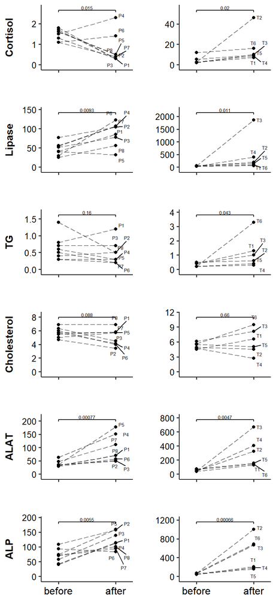

```r
data_file <- here("data","raw","Sieber-Ruckstuhl_Burla_2019_RawData-Annot.xlsx")
d_clinchem_wide <- read_excel(data_file, sheet = "ClinicalChemistry",
                              col_names = TRUE,trim_ws = TRUE,na = c("#N/A", "NULL"), col_types = "guess")

#Conver to long format, use only parameter with numerical value
d_clinchem <- d_clinchem_wide %>%
  select(AnimalID, TreatmentGroup, TreatmentTimePoint, Cortisol, Lipase, TG, Cholesterol, ALAT, ALP) %>%
  gather(key = "Parameter", value =  "Value", -AnimalID:-TreatmentTimePoint, factor_key=TRUE,convert = TRUE)

# re-order the levels in the order of appearance in the dataframe otherwise it plots it in alphabetical order
d_clinchem$TreatmentTimePoint <- factor(d_clinchem$TreatmentTimePoint, levels=c("before","after"))
d_clinchem$AnimalID <- as.factor(d_clinchem$AnimalID)
d_clinchem$TreatmentGroup <- as.factor(d_clinchem$TreatmentGroup)
d_clinchem$Parameter <- as.factor(d_clinchem$Parameter)
d_clinchem$Value <- as.numeric(d_clinchem$Value)

# Create labels to label points
d_clinchem <- d_clinchem %>% mutate(label=ifelse(TreatmentTimePoint=="before", "", as.character(AnimalID)))
t.test.log <- function(x,y){t.test(x=log2(x*10),y=log2(y*10),paired = TRUE,var.equal = FALSE)}

paired_plot <- function(d_filt, var,plotY){
  d_filt_param <- d_filt %>% filter(Parameter==var)
  p<- ggplot(d_filt_param, aes(x=TreatmentTimePoint, y=Value, group=AnimalID)) +
      geom_point(aes(colour=TreatmentTimePoint), size=1.5) +
      geom_line(size=0.5, alpha=0.5,  linetype="longdash") +
      xlab('') +
      scale_colour_manual(values=c("black", "black"), guide=FALSE) +
      ylab(ifelse(plotY, var, "")) +
      scale_y_continuous(expand = c(0.1,0.0)) +
      scale_x_discrete(expand = c(0.1,0.2)) +
      aes(ymin=0) +
      geom_text_repel(label=as.character(d_filt_param$label), size=2, nudge_x=.1, nudge_y=0.1) +
      geom_signif(comparisons  = list(c("before", "after")),
                  textsize = 2, test = "t.test.log", map_signif_level = FALSE,margin_top = 0.15) +
      theme_pubr() +
      theme(axis.title = element_text(face = "bold"), axis.text.y = element_text(size=10)) +
      theme(legend.position="none") +
      theme(strip.background = element_blank(),strip.text.x = element_blank())
  return(p)
}


# Create list of plots of parameters from one treament group, remove x-axis text from all except last plot
plt_PRED <- map(.x = c("Cortisol", "Lipase", "TG", "Cholesterol", "ALAT", "ALP"),
                .f = function(x) paired_plot(d_clinchem[d_clinchem$TreatmentGroup=="PRED",],x, TRUE))
plt_PRED[-length(plt_PRED)] <- map(plt_PRED[-length(plt_PRED)], function(x) x + rremove("x.text"))


plt_ACTH <- map(.x = c("Cortisol", "Lipase", "TG", "Cholesterol", "ALAT", "ALP"),
                .f =function(x) paired_plot(d_clinchem[d_clinchem$TreatmentGroup=="ACTH",],x, FALSE))
plt_ACTH[-length(plt_ACTH)] <- map(plt_ACTH[-length(plt_ACTH)], function(x) x + rremove("x.text"))

# Create a grid from all plots
fig1 <- ggarrange(plotlist=c(rbind(plt_PRED,plt_ACTH)), ncol = 2, nrow = 6, align="h")
ggsave(filename = here("output/figure_1_clinchem.pdf") ,plot = fig1, width = 4, height = 10,units = "in")

plot_grid(plotlist = c(rbind(plt_PRED,plt_ACTH)), align='vh',ncol = 2)
```

## 2) Load and process MS-based lipidomics data

Load raw peak area data, normalize with internal standards, calculate concentrations and perform QC filtering)

```r
#d_conc_wide <- read_csv(here("data/processed/Ruckstuhl_Burla_2019_BeaglePlasmaLipididomeAfterCS_LipidConc_uM.csv"),  col_names = TRUE, trim_ws =TRUE)

data_annot_file = here("data/raw/Sieber-Ruckstuhl_Burla_2019_RawData-Annot.xlsx")
d_conc_wide <- process_ms_dataset(data_annot_file) %>%
                arrange((TreatmentGroup),desc(TreatmentTimePoint),  AnimalID)
```

```
## Median CVA in PRED Group of  PL-CE-DG : 5.294084
## Median CVA in ACTH Group of  PL-CE-DG : 4.495314
## Median CVA in PRED Group of  SL : 12.12434
## Median CVA in ACTH Group of  SL : 10.85775
## Median CVA in PRED Group of  S1P : 8.458341
## Median CVA in ACTH Group of  S1P : 13.13659
## Median CVA in PRED Group of  TG : 18.14693
## Median CVA in ACTH Group of  TG : 18.43279
## Number of species in final filtered dataset:  262
```

```r
write_csv(d_conc_wide,
            here("output", "table_S2_LipidConc_uM_Ruckstuhl_Burla_2019.csv"),
            col_names = TRUE)

d_conc <- d_conc_wide %>% gather(key = Compound, value = Conc, -SampleName:-Sex, factor_key=TRUE) %>%
          add_lipidclass_names()
```

## 3) Figures 2 a/b: Heatmaps and clustering analyses of lipidomes

```r
heatmap_plot <- function(d, grp_colors){

    # Prepare data matrix: Remove annotations remove lipid species containing NAs, Inf and zeros
  d_conc_only <- d %>% select(-SampleName:-Sex) %>%
                    select_if(~ !any(is.na(.)) & !any(is.infinite(.)) & !any(.==0))

  # Log-transform, scale and center data
  m_conc_log <- as.matrix(log2(d_conc_only*100000))
  m_conc_log_norm = scale(m_conc_log, center = TRUE, scale = TRUE)
  rownames(m_conc_log_norm) <- paste0(d$AnimalID,d$TreatmentTimePoint)

  m_conc_log_norm_t <- t(m_conc_log_norm)

  # cluster samples and compoundss
  d1 <- dist(m_conc_log_norm,method = "manhattan", diag = TRUE, upper = TRUE)
  d2 <- dist(m_conc_log_norm_t,method = "maximum", diag = TRUE, upper = FALSE)
  c1 <- hclust(d1, method = "ward.D", members = NULL)
  c2 <- hclust(d2, method = "ward.D2", members = NULL)

  # Create column with color annotations
  color.map <- ifelse(d$TreatmentTimePoint=="after",grp_colors[1], grp_colors[2])

  breaks <- seq(-3,3,length=256)
  # Color gradient
  my_palette <- rev(colorRampPalette(brewer.pal(10, "RdBu"))(255))

  # plot heatmap
  heatmap.2(m_conc_log_norm_t,trace="none",
        Colv=as.dendrogram(c1),
        Rowv=as.dendrogram(c2),
        scale="row",
        col = my_palette,
        ColSideColors=color.map, breaks=breaks,
        dendrogram = "both", xlab = NULL, ylab = NULL,
        margins=c(8,7),cexRow=0.4, cexCol = 1.4, density.info="none",labRow = FALSE,
        key = TRUE)
}

pdf(file = here("output/figure_2ab_clustering.pdf"), width = 5.5, height = 7)
  heatmap_plot(d_conc_wide %>% filter(TreatmentGroup == "ACTH"), c("#E22D01","#ffeeea"))
  heatmap_plot(d_conc_wide %>% filter(TreatmentGroup == "PRED"), c("#0F85DC","#c9dfef"))
dev.off()
```

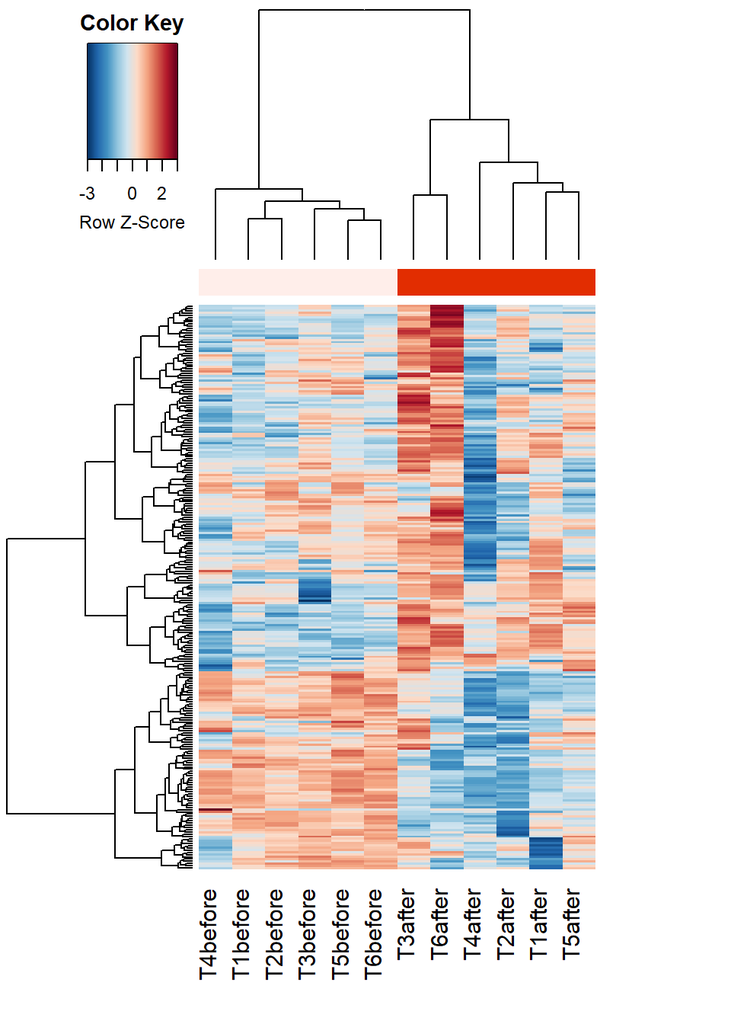

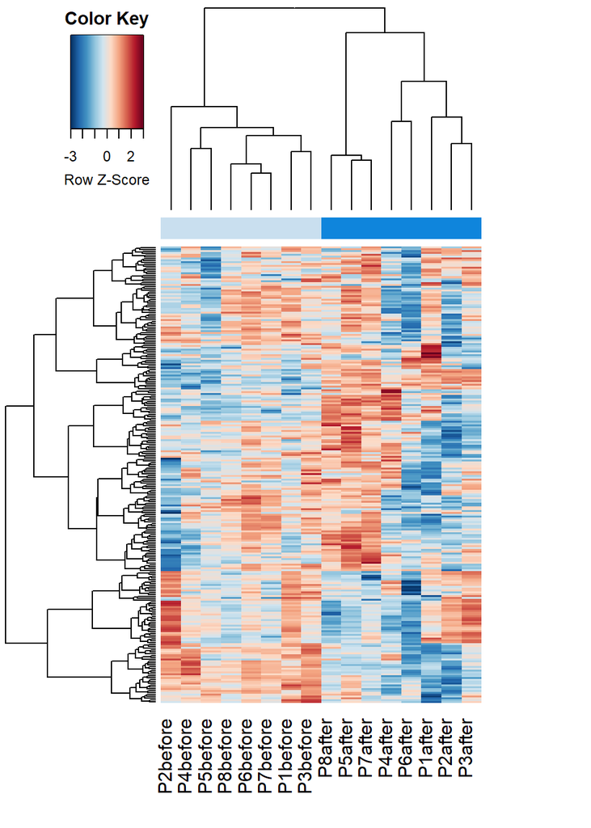

```r
heatmap_plot(d_conc_wide %>% filter(TreatmentGroup == "ACTH"), c("#E22D01","#ffeeea"))
heatmap_plot(d_conc_wide %>% filter(TreatmentGroup == "PRED"), c("#0F85DC","#c9dfef"))
```

## 4) Figures 2 c/d: Principal Component Analyses (PCA) of lipidomes

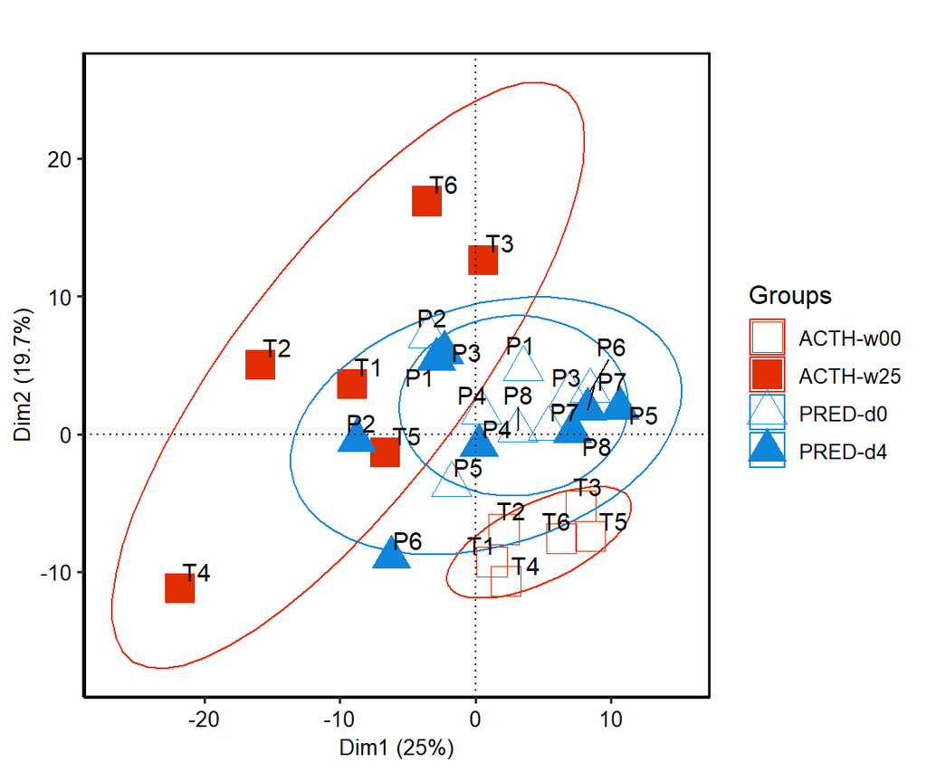

```r
d_conc_pcaplot <- d_conc_wide %>% select(-SampleName:-Sex) %>%
                          select_if(~ !any(is.na(.)) & !any(is.infinite(.)) & !any(.==0))

# Log2 transform the data
d_conc_log_pcaplot <- log2(d_conc_pcaplot*100000)

# Perform PCA and plot the results
res_pca <- prcomp(d_conc_log_pcaplot, center = TRUE, scale. = TRUE)

pca_plot <- function(comp_x, comp_y){
  fviz_pca_ind(res_pca,
    axes = c(comp_x,comp_y),
    palette=c("#E22D01","#E22D01", "#0F85DC", "#0F85DC"),
    habillage=d_conc_wide$ExperimentalGroup,
    addEllipses=TRUE,
    ellipse.level=0.8,
    ellipse.alpha = 0,
    ellipse.line.size=1,
    mean.point = FALSE,
    pointsize = 6.2,
    label="none",
    title = "",
    axes.linetype = "dotted") +
  scale_shape_manual(values = c(0, 15, 2,17)) +
  geom_text_repel(aes(label=as.character(d_conc_wide$AnimalID)), size=4, nudge_x=0.6, nudge_y=0.6)+
  mytheme
}
fig_1C <- pca_plot(comp_x = 1,comp_y = 2)
ggsave(filename = here("output/figure_2c_PCA-dim12.pdf"),plot = fig_1C, width = 6.2, height = 5)
fig_1C
```

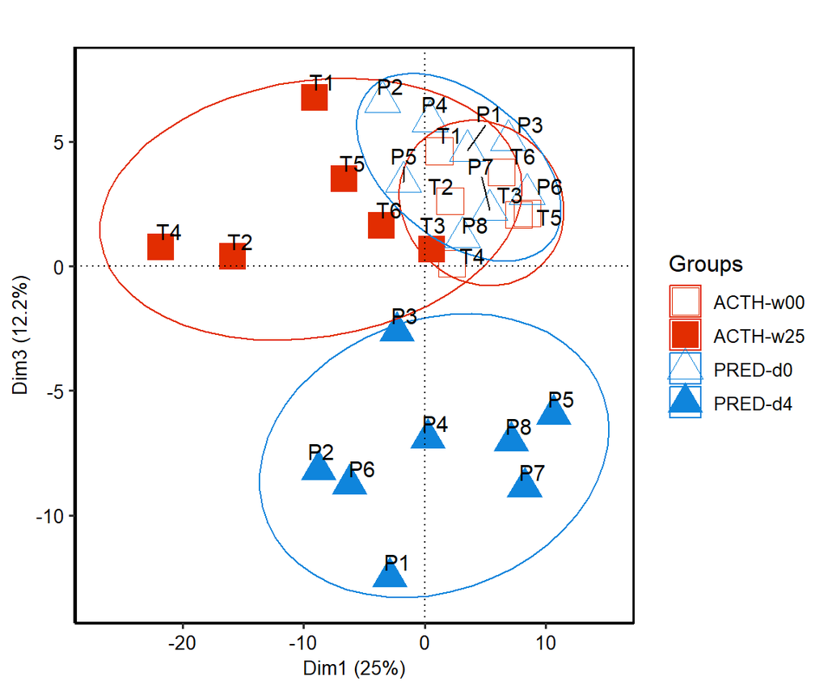

```r
fig_1D <- pca_plot(comp_x = 1, comp_y = 3)
ggsave(filename = here("output/figure_2d_PCA-dim13.pdf"),plot = fig_1D, width = 6.2, height = 5)
fig_1D
```

## 5) Calculate fold-changes and P values before/after treatment

Calculate individual and average fold changes before/after treatments, and FDR-adjusted P values from paired t-tests

```r
get_FC_stat_summary <- function(d_Conc_local){
  # Get data frame with fold changes before vs. after treatment for each species/experimental group
  d_FC <- d_Conc_local %>%
  group_by(TreatmentGroup, AnimalID, Sex, lipidClassBase, lipidClass, isPUFA, Compound, add = FALSE)  %>%
    summarise(log2FC = log2(Conc[TreatmentTimePoint=="after"]/Conc[TreatmentTimePoint=="before"]))

  # Obtain P value from paired t-test (incomplete cases are removed, i.e. species with one or more zero or NA)
  d_FC_stat <- d_Conc_local %>%
    group_by(Compound, TreatmentGroup) %>%
       mutate (log2Conc = log2(Conc)) %>%
       filter(sum(is.infinite(log2Conc) | is.na(log2Conc)) == 0) %>%
       do(summarise(.,p_value_tLOG = t.test(log2Conc ~ TreatmentTimePoint,
                                            var.equal=FALSE, paired=TRUE)$p.value))
  # Calculate FDR-adjusted P values
  d_FC_stat <- d_FC_stat %>%
    group_by(TreatmentGroup, add = FALSE) %>%
     do(mutate(.,fdr_tLOG = p.adjust(p_value_tLOG, "fdr")))

  # Calculare average fold changes and combine with P values
  d_FC_summary <- d_FC %>%
    group_by(Compound, lipidClass, lipidClassBase, TreatmentGroup) %>%
      mutate(log2FC = ifelse(is.infinite(log2FC),NA,log2FC)) %>%
       summarise(meanLog2FC = mean(log2FC, na.rm=TRUE),
                 sdLog2FC = sd(log2FC, na.rm=TRUE),
                 meanFC = 2^abs(meanLog2FC)*sign(meanLog2FC)) %>%
    left_join(d_FC_stat)
  return(list("FC" = d_FC, "summary" = d_FC_summary))
}

# Calculate comparisons for the complete dataset (used in Figures 2 e/f and Figures 3-6)
fc_summary_all <- get_FC_stat_summary(d_conc)
```

## 6) Figures 2 e/f: PCA of lipid fold changes in all indiviuals

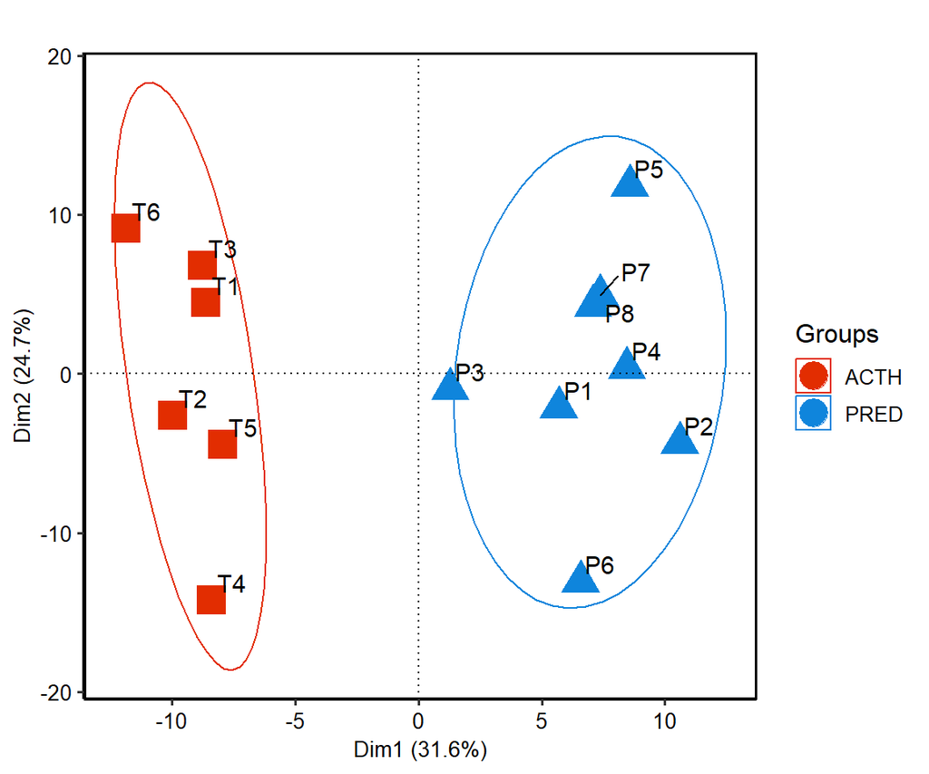

```r
d_FC_wide  <- fc_summary_all$FC %>% ungroup() %>%
                select(-lipidClassBase, -lipidClass,-isPUFA) %>%
                spread(key = Compound , value = log2FC) %>%
                select_if(~ !any(is.na(.)) & !any(is.infinite(.)) & !any(.==0))

# Perform PCA and plot the results
res_pca <- prcomp(d_FC_wide %>% select(-TreatmentGroup:-Sex), center = TRUE, scale. = TRUE)


d_FC_wide$TreatmentGroup_shape <- ifelse(d_FC_wide$TreatmentGroup == "ACTH", 15, 17)

pca_plot_FC <- function(comp_x, comp_y, habillage, group_colors){
              fviz_pca_ind(res_pca,
                axes = c(comp_x,comp_y),
                palette=group_colors,
                habillage=factor(as.factor(habillage)),
                addEllipses=TRUE,
                ellipse.level=0.8,
                ellipse.alpha = 0,
                ellipse.line.size=1,
                mean.point = FALSE,
                pointsize = 6,
                pointshape = d_FC_wide$TreatmentGroup_shape,
                pointcolour = d_FC_wide$TreatmentGroup,
                label="none",
                title = "",
                legend = "Groups",
                axes.linetype = "dotted") +
              scale_shape_manual(values = c(15, 17)) +
              geom_text_repel(aes(label=as.character(d_FC_wide$AnimalID)), size=4, nudge_x=0.6, nudge_y=0.6)+
              mytheme
            }
fig_1E <- pca_plot_FC(comp_x = 1, comp_y = 2,
                      habillage = d_FC_wide$TreatmentGroup,
                      group_colors = c("#E22D01","#0F85DC"))
fig_1F <- pca_plot_FC(comp_x = 3, comp_y = 4,
                      habillage = d_FC_wide$Sex,
                      group_colors = c("#923D97","#0CB1A4"))
ggsave(filename = here("output/figure_2e_PCA_FC_dim12.pdf"),plot = fig_1E, width = 5.88, height = 5)
fig_1E
```

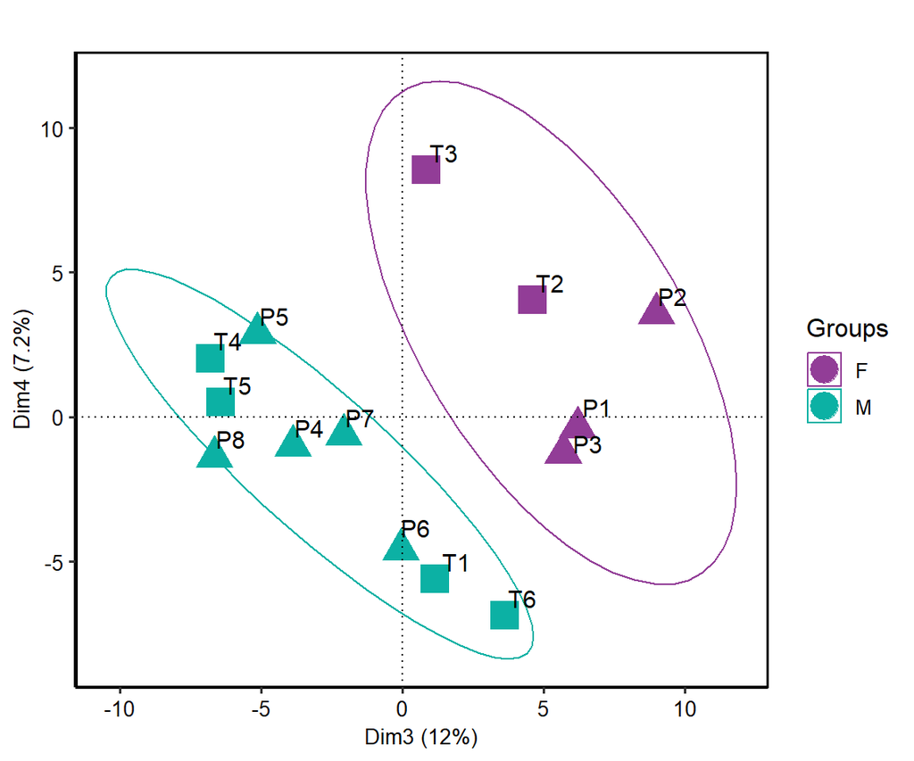

```r
ggsave(filename = here("output/figure_2f_PCA_FC_dim34.pdf"),plot = fig_1F, width = 5.65, height = 5)
fig_1F
```

Warnings are from fviz_pca_ind, with no effect on the data, figure (arises from line ‘pointshape = d_FC_wide$TreatmentGroup_shape’). Fill color of points from individuals were changed in Illustrator to colors of experimental groups (see Fig. 2E)

## 7) Figure 5 b: Total levels of phospholipid species with ≤3 and ≥4 double bonds

P values from t-tests comparing total levels of PUFA and non-PUFA containg species before and after treatments are shown after the figure.

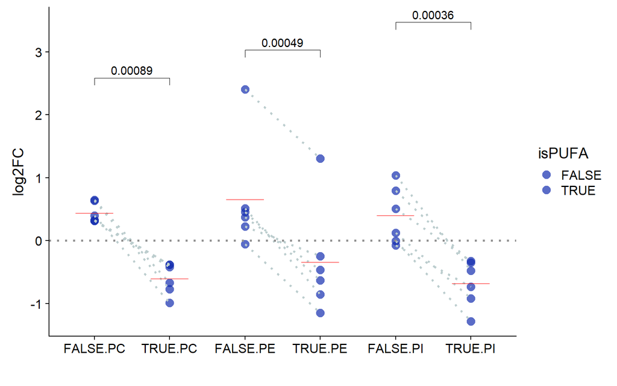

| Compound | lipidClass | TreatmentGroup | meanLog2FC | sdLog2FC | meanFC | p_value_tLOG |
| --- | --- | --- | --- | --- | --- | --- |
| PC_noPUFA | PC | ACTH | 0.4395451 | 0.1590732 | 1.356177 | 0.0010699 |
| PC_PUFA | PC | ACTH | -0.6020994 | 0.2512041 | -1.517924 | 0.0020342 |
| PE_noPUFA | PE | ACTH | 0.6524403 | 0.8811737 | 1.571825 | 0.1294618 |
| PE_PUFA | PE | ACTH | -0.3404415 | 0.8654447 | -1.266144 | 0.3795205 |
| PI_noPUFA | PI | ACTH | 0.3980387 | 0.4564586 | 1.317715 | 0.0857512 |
| PI_PUFA | PI | ACTH | -0.6802670 | 0.3730563 | -1.602436 | 0.0065998 |

```r
# Calculate total levels per lipid class per individual
# To be able to use function "get_FC_stat_summary" variables Conc/Compound are assigned with the total conc/lipid class


plot_nonPUFA_vs_PUFA <- function(d_conc, filename ){
  d_conc_lipidclass <- d_conc %>%
  group_by(TreatmentGroup, AnimalID, Sex, lipidClass, isPUFA, TreatmentTimePoint) %>%
  summarise(Conc = sum(Conc,na.rm = TRUE),
            Compound = paste0(lipidClass[1],ifelse(isPUFA[1], "_PUFA","_noPUFA" )),
            lipidClassBase = lipidClassBase[1]) %>% ungroup()

  fc_summary_lipidClasses <- get_FC_stat_summary(d_conc_lipidclass)
  d_FC_temp <- fc_summary_lipidClasses$FC %>%
    filter(lipidClass == "PC" | lipidClass == "PE"| lipidClass == "PI", TreatmentGroup == "ACTH")

  my_comparisons <- list( c("FALSE.PC", "TRUE.PC"), c("FALSE.PE", "TRUE.PE"), c("FALSE.PI", "TRUE.PI"))

  fig_5B <- ggplot(d_FC_temp, aes( x=interaction(isPUFA, lipidClass), y = log2FC )) +
    geom_point(size=3.3,alpha=0.7, aes(shape=isPUFA), color="#142EAF", fill="#142EAF") +
    geom_line(size=1, aes(group = interaction(AnimalID, lipidClass)),linetype="dotted", color="#BCCDCE") +
    scale_shape_manual(values=c(16,16)) +
    scale_fill_manual(values=c("#142EAF", "#142EAF")) +
    scale_color_manual(values=c("#142EAF", "#142EAF")) +
    stat_summary(fun.data="plot.mean", geom="errorbar", width=0.5, size=.3, color="red",
                 inherit.aes=TRUE,position=position_dodge(0.6)) +
    geom_hline(yintercept = 0, linetype="dotted", size=1, color = "#919191") +
    stat_compare_means(method = "t.test", paired = TRUE, comparisons = my_comparisons, label = "p.format") +
    xlab("")
  plot(fig_5B)


  pvalues <- fc_summary_lipidClasses$summary %>% ungroup() %>%
    select(-lipidClassBase, -fdr_tLOG) %>%
    filter(lipidClass == "PC" | lipidClass == "PE"| lipidClass == "PI", TreatmentGroup == "ACTH")
  ggsave(filename = here("output", filename), plot = fig_5B, width = 6, height = 3.7)
  knitr::kable(pvalues)
}

plot_nonPUFA_vs_PUFA(d_conc, "figure_5b_nonPUFAvsPUFA.pdf")
```

## 8) Figures 3/4/5/6: Heatmaps with individual/average fold changes and P / FDR values

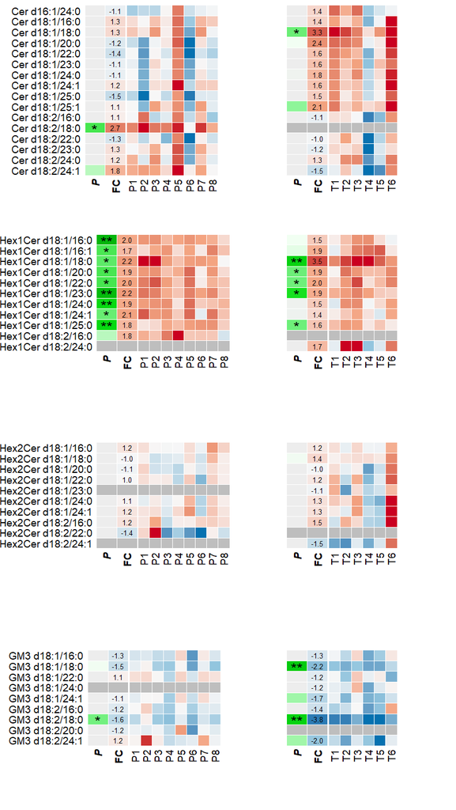

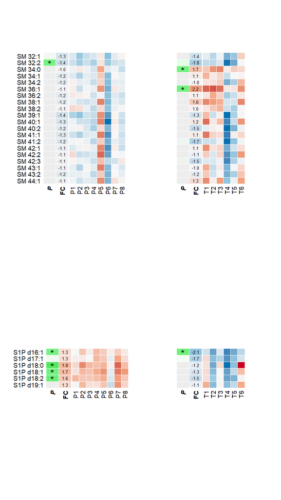

```r
# Each final heatmap consists of 3 fused heatmaps for meanFC, P value and individual FC

# Define color palette and legend for FC
FC_palette <- colorRamp2(breaks = c(-2,-1, 0, 1, 2), colors = rev(brewer.pal(5, "RdBu")),space = "RGB")
fc_lgd = Legend(title = "log2(FC)", col = FC_palette, at = c(-2,-1,0,1,2),
                labels = c("-2", "-1", "0" , "1", "2"),legend_height= unit(5, "cm"))

# Define color palette and legend for P values
pvalue_palette = colorRamp2(breaks = c(0,-log10(0.2), 1,-log10(0.05), 2,-log10(0.002)),
                              colors = c("#ededed", "#ededed", "#f2fff3", "#7ff48c", "#07E012", "#017002"),
                              space = "RGB")
pvalue_lgd = Legend(title = "p-value", col = pvalue_palette,
                      at = c(-log10(0.2), 1,-log10(0.05), 2,-log10(0.002)),
                      labels = c("0.2", "0.1", "0.05", "0.01", "0.002"),legend_height= unit(5, "cm"))

# Function generating the complete heatmap with columns for average FC and P value
plot_heatmap <- function(fc_summary_object, cmpd_filter, treatment_group_filter, show_row_names){

  # Constants
  LOG_FC_MAX_PLOT = 2

  # Used to set name of ComplexHeatmaps (they cannot contain numbers)
  cmpd_filter_charonly =  str_extract(cmpd_filter, "([a-zA-Z])+")

  # Filter dataset for specified lipd class and group and convert to matrix
  m_IndFC <- fc_summary_object$FC %>% mutate(log2FC = ifelse(is.infinite(log2FC),NA,log2FC)) %>%
                        filter(TreatmentGroup==treatment_group_filter, str_detect(Compound, cmpd_filter)) %>%
                        ungroup() %>%
                        select(-Sex, -TreatmentGroup, -lipidClass, -lipidClassBase, -isPUFA) %>%
                        spread(key = AnimalID, value = log2FC) %>%
                        column_to_rownames("Compound") %>%
                        as.matrix() %>% t()
  class(m_IndFC) <- "numeric"

  # Obtain heatmap with individual fold changes
  hm_IndvFC = Heatmap(t(m_IndFC), name = paste0("hm_IndvFC", cmpd_filter_charonly, treatment_group_filter),
              col = FC_palette,
              width = unit(nrow(m_IndFC) * 2.8 , "mm"),
              height = unit(ncol(m_IndFC) * 2.6, "mm"),
              show_row_names = FALSE,
              show_column_names = TRUE,
              column_names_rot = 90,
              column_names_gp = gpar(fontsize = 07, fontface="plain"),
              cluster_rows = FALSE,cluster_columns = FALSE,
              show_heatmap_legend = FALSE,
              rect_gp = gpar(col = "white", lty = 1, lwd = 0.3))

  # Prepare FC and P value matrix (i.e. truncate FC at +/- 2)
  d_sum <- fc_summary_object$summary %>%
    mutate(log_p_value = -log10(fdr_tLOG),
           fdr_tLOG = ifelse(is.na(fdr_tLOG), 1, fdr_tLOG),
           signif_text = cut(fdr_tLOG, c(0,0.001,0.01, 0.05, 0.1,1),
                             labels=c("***","**","*","",""), right=TRUE),
           FC_text = as.character(ifelse(!is.nan(meanFC), sprintf("%0.1f", round(meanFC, digits = 1)),"")),
           meanlog2FC_cut = ifelse(abs(meanLog2FC)>LOG_FC_MAX_PLOT,
                                   sign(meanLog2FC)*LOG_FC_MAX_PLOT, meanLog2FC)) %>%
    filter(TreatmentGroup==treatment_group_filter, str_detect(Compound, cmpd_filter))

  # obtain heatmap column with P values
  m_sum_p <- d_sum  %>% ungroup() %>% select(log_p_value) %>% rename( P = log_p_value)  %>%  as.matrix()
  rownames(m_sum_p) <- d_sum$Compound
  hm_pvalue= Heatmap(m_sum_p, name = paste0("hm_pvalue", cmpd_filter_charonly, treatment_group_filter),
                width = unit(5, "mm"),
                height = unit(ncol(m_IndFC) * 2.6, "mm"),
                col=pvalue_palette,  cluster_rows = FALSE,cluster_columns = FALSE,
                rect_gp = gpar(col = "white", lty = 1, lwd = 0.3),
                show_row_names = show_row_names,
                row_names_side = "left",
                row_names_gp = gpar(fontsize = 7),
                show_column_names = TRUE,
                column_names_rot = 90,
                column_names_gp = gpar(fontsize = 07, fontface="bold.italic"),
                show_heatmap_legend = FALSE,
                cell_fun = function(j, i, x, y, width, height, fill) {
                  grid.text(sprintf("%s", d_sum$signif_text[i]), x = x, y = y- unit(c(0.5), "mm"),
                            gp = gpar(fontsize = 10))})

  # obtain heatmap column with average fold changes
  m_sum_FC <- d_sum  %>% ungroup()%>%  select(meanlog2FC_cut) %>% rowMeans() %>%  as.matrix()
  colnames(m_sum_FC) <- c("FC")
  hm_meanFC = Heatmap(m_sum_FC, name = paste0("hm_meanFC", cmpd_filter_charonly, treatment_group_filter),
                col = FC_palette,
                width = unit(5, "mm"),
                height = unit(ncol(m_IndFC) * 2.6, "mm"),
                cluster_rows = FALSE,cluster_columns = FALSE,
                rect_gp = gpar(col = "white", lty = 1, lwd = 0.3),
                show_row_names = FALSE,
                show_column_names = TRUE,
                column_names_rot = 90,
                column_names_gp = gpar(fontsize = 07, fontface="bold"),
                show_heatmap_legend = FALSE,
                cell_fun = function(j, i, x, y, width, height, fill) {
                  grid.text(sprintf("%s", d_sum$FC_text[i]), x, y, gp = gpar(fontsize = 5))})

  # combine heatmaps
  a <- draw(hm_pvalue + hm_meanFC + hm_IndvFC, gap = unit(c(0, 0.02), "cm"),
            show_heatmap_legend = FALSE,
            newpage = FALSE)

  # draw borders around heatmap segments
  add_borders <- function(heatmap_name, borders_x, borders_y, line_width){
    decorate_heatmap_body(paste0(heatmap_name, cmpd_filter_charonly, treatment_group_filter),
                          {grid.lines(borders_x, borders_y, gp = gpar(col = "#787878", lwd = line_width))})
  }

  add_borders("hm_IndvFC", c(0, 0), c(0,1),1.2)
  add_borders("hm_IndvFC", c(1, 1), c(0,1),1.2)
  add_borders("hm_IndvFC", c(0, 1), c(1,1),1.2)
  add_borders("hm_IndvFC", c(0, 1), c(0,0),1.2)
  add_borders("hm_pvalue", c(0, 1), c(1,1),1.2)
  add_borders("hm_pvalue", c(0, 1), c(0,0),1.2)
  add_borders("hm_pvalue", c(0, 0), c(0,1),1.2)
  add_borders("hm_meanFC", c(0, 1), c(1,1),1.2)
  add_borders("hm_meanFC", c(0, 1), c(0,0),1.2)
  add_borders("hm_meanFC", c(1, 1), c(0,1),1.2)
  draw(a)
  return(a)
}


# combine heatmaps for both experimental groups
plot_FC_heatmap_figure <- function(fc_summary_object, lipidclasses){
  i = 1
  plt_acth <- list()
  plt_pred <- list()
  for(lipidclass in lipidclasses){
    plt_pred[[i]] <- grid.grabExpr(plot_heatmap(fc_summary_object, lipidclass,"PRED", show_row_names = TRUE))
    plt_acth[[i]] <- grid.grabExpr(plot_heatmap(fc_summary_object, lipidclass,"ACTH", show_row_names = FALSE))
    i = i + 1
  }
  plot_grid(plotlist = c(rbind(plt_pred,plt_acth)), align='vh',axis = "r",ncol = 2)
}

# draw heatmaps for different lipid classes
pdf(file = here("output/figure_3-6_heatmaps.pdf"), width = 5 , height = 9)
  plot_FC_heatmap_figure(fc_summary_all, c("^Cer","Hex1Cer", "Hex2Cer", "^GM3"))
  plot_FC_heatmap_figure(fc_summary_all, c("SM", "S1P"))
```

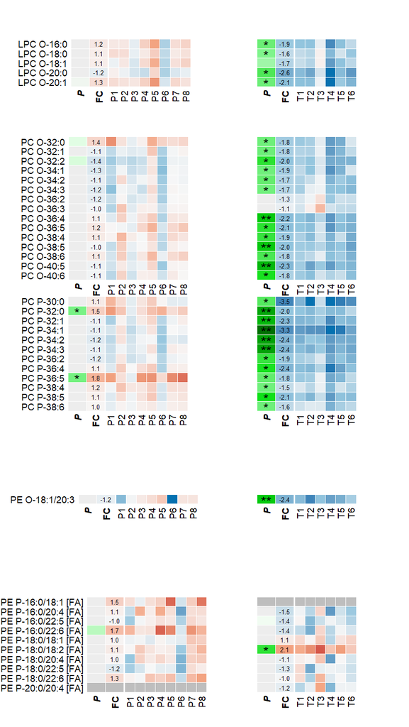

```r
  plot_FC_heatmap_figure(fc_summary_all, c("^LPC O","^PC O", "PC P", "^PE O","^PE P"))
```

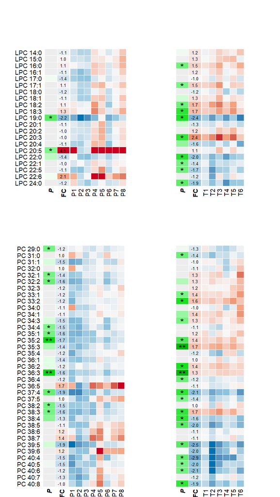

```r
  plot_FC_heatmap_figure(fc_summary_all, c("^LPC [0-9]+","^PC [0-9]+"))
```

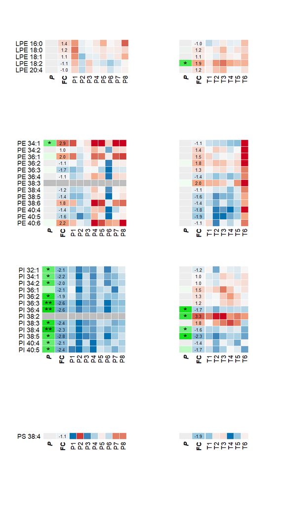

```r
  plot_FC_heatmap_figure(fc_summary_all, c("^LPE [0-9]+","^PE [0-9]+","^PI", "^PS"))
```

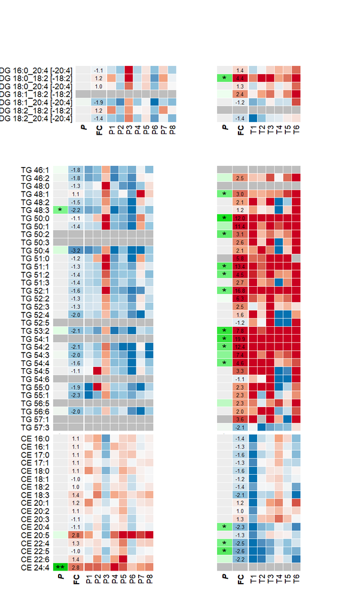

```r
  plot_FC_heatmap_figure(fc_summary_all, c("DG ","TG ", "CE "))
```

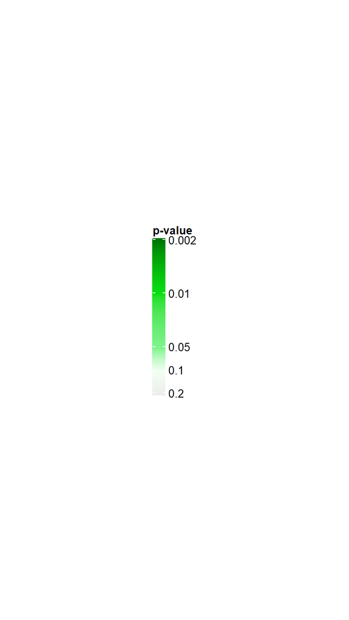

```r
  plot.new()
  draw(pvalue_lgd)
```

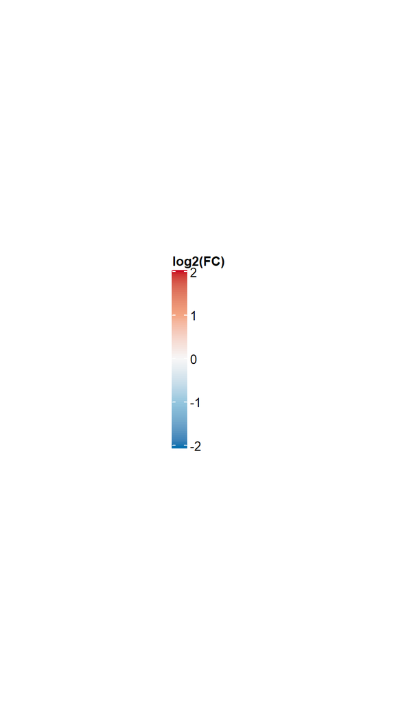

```r
  plot.new()
  draw(fc_lgd)
```

```r
dev.off()
```

## 9) Supplementary Table S3: Fold changes and p/FDR values

```r
get_table_FC_stats <- function(fc_summary_object, filter_exp_group, filter_lipid_class){

  tbl <- fc_summary_object$FC %>% filter(TreatmentGroup==filter_exp_group, str_detect(Compound, filter_lipid_class)) %>%
            ungroup() %>%
                  dplyr::select(Compound, TreatmentGroup,AnimalID,log2FC) %>%
                  spread(key = AnimalID, value = log2FC) %>%
                  left_join(fc_summary_object$summary %>%
                              filter(TreatmentGroup==filter_exp_group, str_detect(Compound, filter_lipid_class)),
                            by = c("Compound","TreatmentGroup")) %>%
            select(-lipidClass,-lipidClassBase)

}

d_FC_report_Pred <- get_table_FC_stats(fc_summary_all, "PRED", "")
d_FC_report_ACTH <- get_table_FC_stats(fc_summary_all, "ACTH", "")
d_FC_report <- d_FC_report_Pred %>% left_join(d_FC_report_ACTH, by=(c("Compound")))

write_csv(d_FC_report, path =  here("output/table_S3_summary_FC_Pvalues_allsamples.csv"))
```

## 10) Supplementary Tables S5/S6/S7: Excluding specific dogs

```r
fc_summary_noT4 <- get_FC_stat_summary(d_conc %>% filter(AnimalID !="T4"))
fc_summary_noT6 <- get_FC_stat_summary(d_conc %>% filter(AnimalID !="T6"))
fc_summary_noP3 <- get_FC_stat_summary(d_conc %>% filter(AnimalID !="P3"))

t_summary_noT4 <- get_table_FC_stats(fc_summary_noT4,"ACTH", "Cer")
t_summary_noT6 <- get_table_FC_stats(fc_summary_noT6,"ACTH", "PE [0-9]+")
t_summary_noP3 <- get_table_FC_stats(fc_summary_noP3,"PRED", "^DG|^TG")

write_csv(t_summary_noT4, path = here("output/table_S5_summary_noT4_Cer.csv"))
write_csv(t_summary_noT6, path = here("output/table_S6_summary_noT6_LPE-PE.csv"))
write_csv(t_summary_noP3, path = here("output/table_S7_summary_noP3_DG-TG.csv"))

knitr::kable(t_summary_noT4 %>% select(-T1:-T6) ,digits = 3, caption = "no T4")
```

no T4

| Compound | TreatmentGroup | meanLog2FC | sdLog2FC | meanFC | p_value_tLOG | fdr_tLOG |
| --- | --- | --- | --- | --- | --- | --- |
| Cer d16:1/24:0 | ACTH | 0.731 | 0.940 | 1.659 | 0.157 | 0.251 |
| Cer d18:1/16:0 | ACTH | 0.876 | 0.848 | 1.836 | 0.082 | 0.154 |
| Cer d18:1/18:0 | ACTH | 1.988 | 0.746 | 3.967 | 0.004 | 0.036 |
| Cer d18:1/20:0 | ACTH | 1.545 | 1.028 | 2.918 | 0.028 | 0.075 |
| Cer d18:1/22:0 | ACTH | 1.090 | 0.611 | 2.128 | 0.016 | 0.054 |
| Cer d18:1/23:0 | ACTH | 1.071 | 0.346 | 2.100 | 0.002 | 0.029 |
| Cer d18:1/24:0 | ACTH | 1.104 | 0.646 | 2.150 | 0.019 | 0.061 |
| Cer d18:1/24:1 | ACTH | 0.977 | 0.760 | 1.969 | 0.045 | 0.101 |
| Cer d18:1/25:0 | ACTH | 0.799 | 0.692 | 1.740 | 0.061 | 0.127 |
| Cer d18:1/25:1 | ACTH | 1.173 | 0.769 | 2.254 | 0.027 | 0.074 |
| Cer d18:2/16:0 | ACTH | 0.142 | 0.854 | 1.103 | 0.730 | 0.796 |
| Cer d18:2/18:0 | ACTH | NaN | NaN | NaN | NA | NA |
| Cer d18:2/22:0 | ACTH | 0.318 | 0.679 | 1.247 | 0.354 | 0.445 |
| Cer d18:2/23:0 | ACTH | 0.267 | 0.359 | 1.203 | 0.172 | 0.270 |
| Cer d18:2/24:0 | ACTH | 0.729 | 0.892 | 1.657 | 0.142 | 0.231 |
| Cer d18:2/24:1 | ACTH | -0.054 | 1.149 | -1.038 | 0.921 | 0.959 |
| Hex1Cer d18:1/16:0 | ACTH | 0.484 | 0.512 | 1.399 | 0.102 | 0.182 |
| Hex1Cer d18:1/16:1 | ACTH | 0.775 | 0.807 | 1.712 | 0.098 | 0.179 |
| Hex1Cer d18:1/18:0 | ACTH | 1.703 | 0.498 | 3.257 | 0.002 | 0.023 |
| Hex1Cer d18:1/20:0 | ACTH | 0.973 | 0.580 | 1.963 | 0.020 | 0.063 |
| Hex1Cer d18:1/22:0 | ACTH | 1.110 | 0.543 | 2.159 | 0.010 | 0.043 |
| Hex1Cer d18:1/23:0 | ACTH | 0.910 | 0.364 | 1.879 | 0.005 | 0.036 |
| Hex1Cer d18:1/24:0 | ACTH | 0.745 | 0.695 | 1.676 | 0.075 | 0.144 |
| Hex1Cer d18:1/24:1 | ACTH | 0.481 | 0.565 | 1.396 | 0.130 | 0.218 |
| Hex1Cer d18:1/25:0 | ACTH | 0.758 | 0.376 | 1.691 | 0.011 | 0.043 |
| Hex1Cer d18:2/16:0 | ACTH | NaN | NaN | NaN | NA | NA |
| Hex1Cer d18:2/24:0 | ACTH | 1.164 | 1.373 | 2.240 | 0.131 | 0.219 |
| Hex2Cer d18:1/16:0 | ACTH | 0.287 | 0.450 | 1.220 | 0.226 | 0.328 |
| Hex2Cer d18:1/18:0 | ACTH | 0.462 | 0.484 | 1.378 | 0.100 | 0.180 |
| Hex2Cer d18:1/20:0 | ACTH | 0.266 | 0.783 | 1.203 | 0.489 | 0.573 |
| Hex2Cer d18:1/22:0 | ACTH | 0.513 | 0.963 | 1.427 | 0.299 | 0.402 |
| Hex2Cer d18:1/23:0 | ACTH | 0.011 | 1.043 | 1.008 | 0.982 | 0.988 |
| Hex2Cer d18:1/24:0 | ACTH | 0.574 | 1.261 | 1.489 | 0.366 | 0.457 |
| Hex2Cer d18:1/24:1 | ACTH | 0.508 | 1.237 | 1.422 | 0.410 | 0.502 |
| Hex2Cer d18:2/16:0 | ACTH | 0.828 | 1.946 | 1.775 | 0.395 | 0.491 |
| Hex2Cer d18:2/22:0 | ACTH | NaN | NaN | NaN | NA | NA |
| Hex2Cer d18:2/24:1 | ACTH | -0.448 | 1.299 | -1.365 | 0.483 | 0.570 |

```r
knitr::kable(t_summary_noT6 %>% select(-T1:-T5) ,digits = 3, caption = "no T6")
```

no T6

| Compound | TreatmentGroup | meanLog2FC | sdLog2FC | meanFC | p_value_tLOG | fdr_tLOG |
| --- | --- | --- | --- | --- | --- | --- |
| LPE 16:0 | ACTH | -0.223 | 0.294 | -1.167 | 0.166 | 0.284 |
| LPE 18:0 | ACTH | 0.260 | 0.368 | 1.198 | 0.189 | 0.309 |
| LPE 18:1 | ACTH | 0.072 | 0.248 | 1.051 | 0.551 | 0.649 |
| LPE 18:2 | ACTH | 0.970 | 0.474 | 1.958 | 0.010 | 0.045 |
| LPE 20:4 | ACTH | 0.317 | 0.423 | 1.246 | 0.169 | 0.287 |
| PE 34:1 | ACTH | -0.775 | 0.249 | -1.711 | 0.002 | 0.025 |
| PE 34:2 | ACTH | 0.082 | 0.403 | 1.058 | 0.673 | 0.754 |
| PE 36:1 | ACTH | 0.070 | 0.331 | 1.050 | 0.660 | 0.745 |
| PE 36:2 | ACTH | 0.505 | 0.211 | 1.419 | 0.006 | 0.033 |
| PE 36:3 | ACTH | 0.163 | 0.262 | 1.120 | 0.236 | 0.364 |
| PE 36:4 | ACTH | -0.811 | 0.266 | -1.755 | 0.002 | 0.025 |
| PE 38:3 | ACTH | 0.655 | 0.529 | 1.575 | 0.050 | 0.109 |
| PE 38:4 | ACTH | -0.465 | 0.372 | -1.380 | 0.049 | 0.108 |
| PE 38:5 | ACTH | -1.020 | 0.546 | -2.027 | 0.014 | 0.052 |
| PE 38:6 | ACTH | -0.806 | 0.395 | -1.748 | 0.010 | 0.045 |
| PE 40:4 | ACTH | -1.375 | 0.819 | -2.594 | 0.020 | 0.062 |
| PE 40:5 | ACTH | -1.314 | 0.730 | -2.486 | 0.016 | 0.056 |
| PE 40:6 | ACTH | -0.468 | 0.866 | -1.384 | 0.293 | 0.422 |

```r
knitr::kable(t_summary_noP3 %>% select(-P1:-P8),digits = 3, caption = "no P3")
```

no P3

| Compound | TreatmentGroup | meanLog2FC | sdLog2FC | meanFC | p_value_tLOG | fdr_tLOG |
| --- | --- | --- | --- | --- | --- | --- |
| DG 16:0_20:4 [-20:4] | PRED | -0.480 | 0.619 | -1.395 | 0.086 | 0.211 |
| DG 18:0_18:2 [-18:2] | PRED | -0.047 | 0.955 | -1.033 | 0.901 | 0.951 |
| DG 18:0_20:4 [-20:4] | PRED | -0.148 | 0.652 | -1.108 | 0.569 | 0.710 |
| DG 18:1_18:2 [-18:2] | PRED | NaN | NaN | NaN | NA | NA |
| DG 18:1_20:4 [-20:4] | PRED | -1.162 | 0.763 | -2.238 | 0.007 | 0.045 |
| DG 18:2_18:2 [-18:2] | PRED | 0.133 | 0.905 | 1.097 | 0.710 | 0.820 |
| DG 18:2_20:4 [-20:4] | PRED | -0.804 | 0.658 | -1.746 | 0.018 | 0.075 |
| TG 46:1 | PRED | -1.115 | 0.513 | -2.165 | 0.001 | 0.023 |
| TG 46:2 | PRED | -1.025 | 0.813 | -2.036 | 0.016 | 0.068 |
| TG 48:0 | PRED | -0.734 | 0.810 | -1.663 | 0.053 | 0.149 |
| TG 48:1 | PRED | -0.115 | 1.141 | -1.083 | 0.798 | 0.877 |
| TG 48:2 | PRED | -0.851 | 0.973 | -1.804 | 0.060 | 0.164 |
| TG 48:3 | PRED | -1.394 | 0.533 | -2.627 | 0.000 | 0.023 |
| TG 50:0 | PRED | -0.427 | 1.139 | -1.345 | 0.359 | 0.549 |
| TG 50:1 | PRED | -0.832 | 0.922 | -1.780 | 0.054 | 0.150 |
| TG 50:2 | PRED | NaN | NaN | NaN | NA | NA |
| TG 50:3 | PRED | NaN | NaN | NaN | NA | NA |
| TG 50:4 | PRED | -2.097 | 1.165 | -4.277 | 0.003 | 0.033 |
| TG 51:0 | PRED | -0.667 | 1.347 | -1.588 | 0.238 | 0.409 |
| TG 51:1 | PRED | -0.710 | 0.607 | -1.636 | 0.021 | 0.080 |
| TG 51:2 | PRED | -0.767 | 0.462 | -1.701 | 0.005 | 0.035 |
| TG 51:3 | PRED | -0.779 | 0.349 | -1.716 | 0.001 | 0.023 |
| TG 52:1 | PRED | -1.108 | 0.636 | -2.155 | 0.004 | 0.033 |
| TG 52:2 | PRED | -0.665 | 0.608 | -1.585 | 0.028 | 0.095 |
| TG 52:3 | PRED | -0.619 | 0.450 | -1.536 | 0.011 | 0.053 |
| TG 52:4 | PRED | -1.283 | 1.175 | -2.434 | 0.028 | 0.095 |
| TG 52:5 | PRED | NaN | NaN | NaN | NA | NA |
| TG 53:2 | PRED | -1.381 | 0.699 | -2.605 | 0.002 | 0.028 |
| TG 54:1 | PRED | NaN | NaN | NaN | NA | NA |
| TG 54:2 | PRED | -1.426 | 0.995 | -2.688 | 0.009 | 0.048 |
| TG 54:3 | PRED | -1.318 | 0.845 | -2.494 | 0.006 | 0.042 |
| TG 54:4 | PRED | -0.876 | 0.659 | -1.836 | 0.013 | 0.059 |
| TG 54:5 | PRED | -0.331 | 1.304 | -1.258 | 0.526 | 0.696 |
| TG 54:6 | PRED | NaN | NaN | NaN | NA | NA |
| TG 55:0 | PRED | -1.166 | 1.861 | -2.244 | 0.148 | 0.304 |
| TG 55:1 | PRED | -1.504 | 1.451 | -2.836 | 0.034 | 0.105 |
| TG 56:5 | PRED | NaN | NaN | NaN | NA | NA |
| TG 56:6 | PRED | -1.274 | 1.073 | -2.419 | 0.020 | 0.077 |
| TG 57:1 | PRED | NaN | NaN | NaN | NA | NA |
| TG 57:3 | PRED | NaN | NaN | NaN | NA | NA |

## 11) Supplementary Figures S4 a/b/d: Average FC and p values with/without specific individuals

Comparison of fold changes and p values for all individuals and when specific dogs were excluded from the analysis.

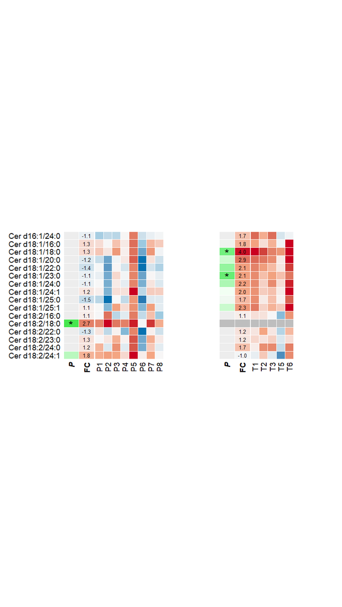

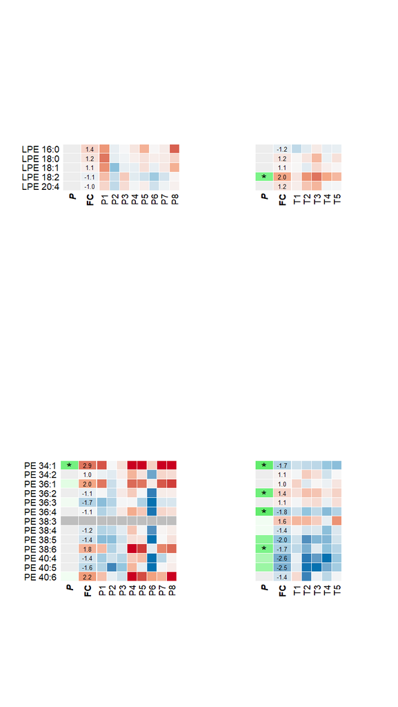

```r
pdf(file = here("output/figure_S4abd_heatmaps.pdf"), width = 5 , height = 9)
  plot_FC_heatmap_figure(get_FC_stat_summary(d_conc %>% filter(AnimalID !="T4")), c("^Cer "))
  plot_FC_heatmap_figure(get_FC_stat_summary(d_conc %>% filter(AnimalID !="T6")), c("^LPE ","^PE [0-9]+"))
```

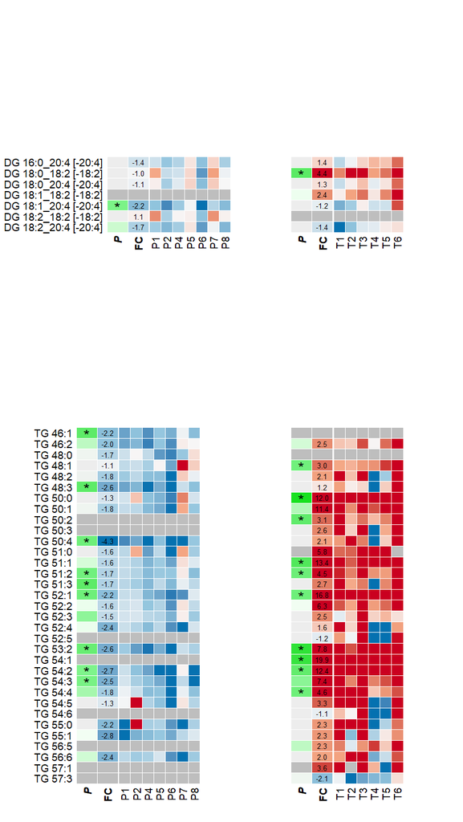

```r
  plot_FC_heatmap_figure(get_FC_stat_summary(d_conc %>% filter(AnimalID !="P3")), c("^DG ","^TG "))
```

```r
dev.off()
```

## 12) Supplementary Figure S4c: Effect of removing T6 on total levels of phospholipid species with ≤3 and ≥4 double bonds

P values from t-tests comparing total levels of PUFA and non-PUFA containg species before and after treatments are shown after the figure.

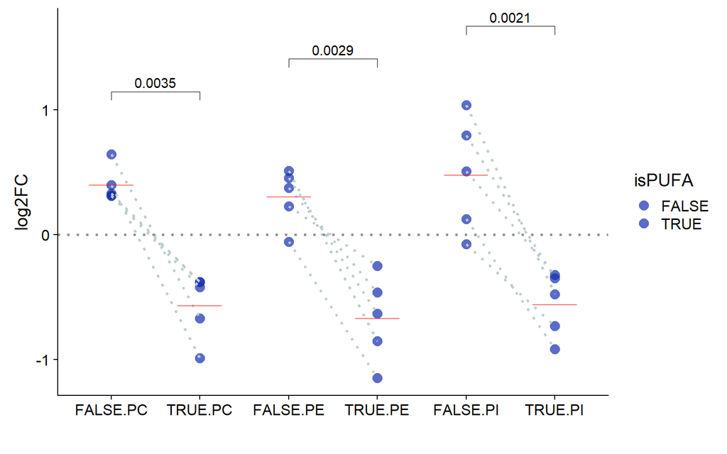

| Compound | lipidClass | TreatmentGroup | meanLog2FC | sdLog2FC | meanFC | p_value_tLOG |
| --- | --- | --- | --- | --- | --- | --- |
| PC_noPUFA | PC | ACTH | 0.4000225 | 0.1411207 | 1.319529 | 0.0031725 |
| PC_PUFA | PC | ACTH | -0.5681856 | 0.2650534 | -1.482658 | 0.0086901 |
| PE_noPUFA | PE | ACTH | 0.3024512 | 0.2277954 | 1.233238 | 0.0411892 |
| PE_PUFA | PE | ACTH | -0.6701828 | 0.3475245 | -1.591275 | 0.0125249 |
| PI_noPUFA | PI | ACTH | 0.4781585 | 0.4607593 | 1.392964 | 0.0810916 |
| PI_PUFA | PI | ACTH | -0.5603591 | 0.2571567 | -1.474636 | 0.0082048 |

```r
plot_nonPUFA_vs_PUFA(d_conc %>% filter(AnimalID != "T6"), "figure_S4c_nonPUFAvsPUFA.pdf")
```

## Source code of “ms_data_preprocessing.R” used in this R notebook

```r
####################################################################################################
# R script used for the normalization and QC filtering of raw results from the lipidomics analyses
#
# 08.01.2019 / Bo Burla
# Singapore Lipidomics Incubator (SLING), National University of Singapore
####################################################################################################

library(here)
library(dplyr)
library(tidyr)
library(stringr)
library(readxl)


# Function to read, normalize and QC filter a dataset with peak areas
# -------------------------------------------------------------------

process_rawdata_panel <- function(data_file, panel_text, ISTDconc_sheet, PeakAreas_sheet, ISTDmap_sheet,
                                  sample_vol, istd_vol,
                                  min_pqc_area_treshold, min_sbr_treshold, max_cva_treshold, species_to_keep){

  # Inport data from Excel workbook
  concISTD <- read_excel(data_file, sheet = ISTDconc_sheet,
                         col_names = TRUE,trim_ws = TRUE,na = c("#N/A", "NULL"), col_types = "guess")
  datWide <- read_excel(data_file, sheet = PeakAreas_sheet,
                        col_names = TRUE,trim_ws = TRUE,na = c("#N/A", "NULL"), col_types = "guess")
  mapISTD <- read_excel(data_file, sheet = ISTDmap_sheet,
                        col_names = TRUE,trim_ws = TRUE,na = c("#N/A", "NULL"), col_types = "guess")

  # Transform data table format from wide to long (tidy) and convert type of Area from int to num
  datLong <- gather(datWide, key="Compound", value="Area",
                    factor_key=FALSE, -RawDataFileName, -SampleName, -AcqDateTime,
                    -SampleType, -AnalyticalGroup)
  datLong <- datLong %>% select(-RawDataFileName,-AcqDateTime )
  datLong$Area <- as.numeric(datLong$Area) %>% replace(is.na(.), 0)

  # ISTD normalization and calculation of concentrations
  #  - Joins a column with ISTD for each compound (based on ISTDmap file), groups by ISTD and
  #    normalizes with the value of the ISTD
  #  - Calculates concentrations (based on ISTD concentrations in the table concISTD and given
  #    sample and ISTD volumes)

  dat_norm <- datLong  %>%
    left_join(mapISTD, c("Compound"="Compound")) %>%
    left_join(concISTD, by=c("ISTD"="ISTD")) %>%
    mutate(isISTD = (Compound == ISTD)) %>%
    group_by(ISTD,SampleName) %>%
          mutate(
            normArea = Area*CF/Area[isISTD]*CF[isISTD],
            uM = normArea*(istd_vol*ISTDconcNGML/ISTD_MW)/sample_vol)

  # Calculate QC metrics (Signal/Blank ratio, analytical CV and median signal of PQCs) for each
  # transition/compound per experimental group
  cmpd_QC <- dat_norm %>%
    filter(SampleType =="PQC" & AnalyticalGroup != "") %>%
    group_by(Compound, Quantifier, isISTD, AnalyticalGroup, SampleType) %>%
    do(
      summarise(.data = .,
                SBR = median(Area,na.rm = TRUE)/max(dat_norm$Area[dat_norm$SampleType == "BLANK" & dat_norm$Compound == unique(Compound)],
                                                    na.rm = TRUE),
                CVA = sd(normArea ,na.rm = TRUE)/mean(normArea,na.rm = TRUE)*100,
                INT = median(Area,na.rm = TRUE)))

  # Get list of compound that fullfill the QC criteria passed as parameter of this funcion
  comp_QC_pass <- cmpd_QC %>% ungroup() %>%
                    filter((INT > min_pqc_area_treshold &
                           SBR > min_sbr_treshold &
                           CVA < max_cva_treshold) | Compound %in% species_to_keep )

  cat("Median CVA in PRED Group of ", panel_text, ":" ,
      median(comp_QC_pass %>% filter(AnalyticalGroup=="PRED" & !isISTD & Quantifier & !str_detect(Compound, "\\(IS")) %>% .$CVA),"\n")
  cat("Median CVA in ACTH Group of ", panel_text, ":" ,
      median(comp_QC_pass %>% filter(AnalyticalGroup=="ACTH" & !isISTD & Quantifier & !str_detect(Compound, "\\(IS")) %>% .$CVA),"\n")

  # Filter the dataset with the list of compounds that passed QC
  dat_norm_filt <- dat_norm %>%
    filter(Quantifier, !isISTD, !str_detect(Compound, "(IS)"), SampleType=="SPL") %>%
    semi_join(comp_QC_pass, by=c("AnalyticalGroup"="AnalyticalGroup", "Compound"="Compound"))

  return (dat_norm_filt)
}


# Process raw data from all 4 panels (PL/DG/CE, SL, TG and S1P) and combine
# -------------------------------------------------------------------------

process_all_panels <- function(data_file){

  sample_annot <- read_excel(data_file, sheet = "SampleAnnotation",
                             col_names = TRUE,trim_ws = TRUE,na = c("#N/A", "NULL"), col_types = "guess")

  d_PL <- process_rawdata_panel(data_file, panel_text = "PL-CE-DG",
                                ISTDconc_sheet = "ISTDconc",
                                PeakAreas_sheet = "Panel1_PL-CE-DG_PeakAreas",
                                ISTDmap_sheet = "Panel1_PL-CE-DG_ISTDmap",
                          sample_vol = 10, istd_vol = 90,
                          min_pqc_area_treshold = 250,  min_sbr_treshold = 5, max_cva_treshold = 25,
                          species_to_keep = "")

  # REMARK: Cer d18:1/18:0 and Hex1Cer d18:1/24:1 had CVs of 27.8% and 30.1% in the prednisolone group, but
  #         were kept in the dataset as they belong to reported the CVD markers and their CVs were 7.3% and
  #         10.9%, respectively, the tetracosactide group.
  d_SL <- process_rawdata_panel(data_file, panel_text = "SL",
                                ISTDconc_sheet = "ISTDconc",
                                PeakAreas_sheet = "Panel2_SL_PeakAreas",
                                ISTDmap_sheet = "Panel2_SL_ISTDmap",
                          sample_vol = 10, istd_vol = 90,
                          min_pqc_area_treshold = 250,  min_sbr_treshold = 5, max_cva_treshold = 25,
                          species_to_keep = c("Cer d18:1/18:0", "Hex1Cer d18:1/24:1"))

  d_S1P <- process_rawdata_panel(data_file, panel_text = "S1P",
                                 ISTDconc_sheet = "ISTDconc",
                                 PeakAreas_sheet = "Panel3_S1P_PeakAreas",
                                 ISTDmap_sheet = "Panel3_S1P_ISTDmap",
                          sample_vol = 10, istd_vol = 90,
                          min_pqc_area_treshold = 250,  min_sbr_treshold = 5, max_cva_treshold = 25,
                          species_to_keep = "")

  d_TG <- process_rawdata_panel(data_file, panel_text = "TG",
                                ISTDconc_sheet = "ISTDconc",
                                PeakAreas_sheet = "Panel4_TG_PeakAreas",
                                ISTDmap_sheet = "Panel4_TG_ISTDmap",
                          sample_vol = 10, istd_vol = 90,
                          min_pqc_area_treshold = 250,  min_sbr_treshold = 5, max_cva_treshold = 25,
                          species_to_keep = "")

  # Substracting interference from the M+2 isotope that were not sufficientlt separated and
  # therefore included in the integrated peak
  #   PC O-36:3: rel. abundance of PC-O-36:3 M+2 ion without phosphocholine)
  #   S1P: see Burla et al, Methods Mol Biol., 2018)

  d_PL <- d_PL %>% mutate(uM = ifelse(Compound == "PC O-36:3",
                                      uM[Compound == "PC O-36:3"] - 0.0982 * uM[Compound == "PC O-36:4"],
                                      uM))
  d_S1P <- d_S1P %>% mutate(uM = ifelse(Compound == "S1P d18:0",
                                        uM[Compound == "S1P d18:0"] - 0.03161 * uM[Compound == "S1P d18:1"],
                                        uM))


  d_final <- bind_rows(d_PL, d_SL, d_TG, d_S1P)
  d_final <- sample_annot %>% left_join(d_final, by=c("SampleName","SampleName"))

  cat(paste0("Number of species in final filtered dataset: "),length(unique(d_final$Compound)))
  return(d_final)
}

# Process raw peak area data from all MS analyses (normalize and QC filter)
# ==========================================================================================


process_ms_dataset <- function(rawdata_file){
  d_final <- process_all_panels(data_file = rawdata_file) %>% rename(Conc = uM)
  d_final_wide_uM <- d_final %>% ungroup() %>%
    select(SampleName, AnimalID, TreatmentGroup, ExperimentalGroup, TreatmentTimePoint,
           Sex, Compound, Conc) %>%
    spread(key = Compound,value = Conc, drop=TRUE) %>%
    arrange(TreatmentGroup, AnimalID)

  return(d_final_wide_uM)
}
```

## Source code of “misc_functions.R” used in this R notebook

```r
##################################################################################
# Misc functions
#
# 20.01.2019 / Bo Burla
# Singapore Lipidomics Incubator (SLING), National University of Singapore
##################################################################################

library(dplyr)
library(tidyr)
library(stringr)
library(ggpubr)

# Reformat lipid names
clean_lipidnames <- function(datLong){
  datLong_clean <- datLong %>%
    mutate(Compound= str_replace(Compound, "\\/C(?=\\d)","\\/")) %>%
    mutate(Compound= str_replace(Compound, "[:space:]C"," "))
  return(datLong_clean)
}

# Retreive lipid class from lipid name
add_lipidclass_names <- function(datLong){
  datLong_temp <- clean_lipidnames(datLong)
  datLong_temp <- datLong_temp %>%
                    mutate(lipidClassBase = str_trim(str_extract(Compound, "[A-z0-9]+[[:blank:]]*")),
                           lipidClass = str_trim(str_extract(Compound, "[A-z0-9]+[[:blank:]]*([A-Z]{1}|[d|t|m][0-9]{2}[:]{1}[0-9]{1})")))

  datLong_temp <- datLong_temp %>%
                    mutate(lipidClass = str_replace(lipidClass, "([[:blank:]]+)([^d|t|m]{1})", "-\\2"),
                           isPUFA = ifelse(str_detect(Compound, "\\:0|\\:1|\\:2|\\:3"),FALSE,TRUE)) %>%
                    select(-Compound, -Conc, Compound, Conc)

  datLong_temp <- datLong_temp %>% mutate_at(.vars = c("lipidClass", "lipidClassBase"), as.factor)
  return(datLong_temp)
}

# Use within stat_summary function to plot median lines
plot.mean <- function(x) {
  m <- mean(x)
  c(y = m, ymin = m, ymax = m)
}

# ggplot theme used for PCA plots
mytheme <- theme_pubr() +
  theme(axis.line = element_line(colour = 'black',size=0.8),
        panel.border = element_rect(colour = "black", fill=NA, size=1),
        axis.text = element_text(size=10),
        axis.title = element_text(size=10),
        legend.position="right")
```